# RRproject: CA Coastal Chinook index of abundance

Shanae Allen-Moran

Tuesday, November 25, 2014

My Reproducible Research class project is to analyze genetic stock identification (GSI) data collected from commercial fishing vessels off the coast of CA and OR from 2010 - 2013. Specifically I standardized average catch per hour fished (CPUE) of California Coastal Chinook (CCC) in order to obtain an index of abundance. We cannot currently assess absolute abundance of this stock using traditional methods (i.e., cohort reconstruction) because we do not have escapement data, nor do we have catch estimates for all fished strata (e.g., coastwide recreational and commercial catch of CCC).

In order to obtain an index of abundance from CPUE data, we have to standardize CPUE to account for factors that may cause the catchability of this stock to vary over time; factors such as the mismatch between stock distribution and fishing effort, and differences in the ability of fisherman to find and catch CCC.

For each vessel and day, CPUE is defined as the average catch of CCC per hour spent actively catching fish. I confirmed that explanatory variables such as latitude and longitude did not vary appreciably per hour and used average lat/lon per day as nonlinear effects. Graphs of the data are presented that illustrate the distribution of CPUE and how CPUE varies over time and space. First, the distribution of log(CPUE + .001) illustrates that CPUE is zero inflated to a high degree but is lognormal or gamma-ish for positive values and highly variable.

```
## stat_bin: binwidth defaulted to range/30. Use 'binwidth = x' to adjust this.
```

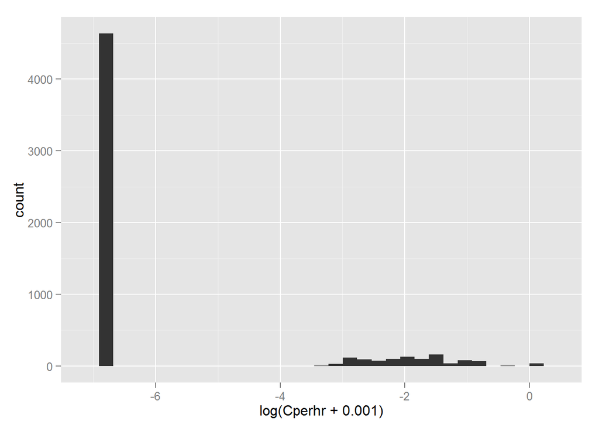

To further analzye the variability of CPUE, the following graphs illustrate how CPUE varies over time and space. I first plot CPUE vs average latitude per day (avglatday) such that each point is CPUE for a particular vessel for all time. I then plot the relationship stratified by month and year. The solid line indicates where the Eel River is located, which is the largest river in the CCC Evolutionarily Significant Unit (ESU). The following plots indicate average CPUE increases just south of the mouth of this river, and as the spawning season begins (~July).

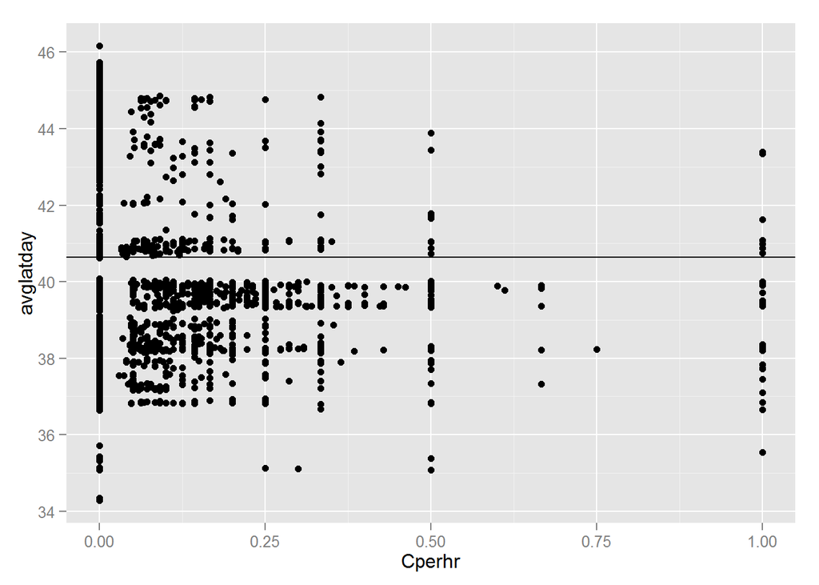

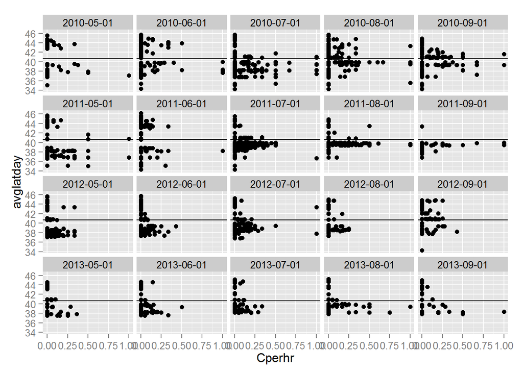

CPUE is also plotted vs average longitude per day (avglonday) and the longitude of the mouth of the Eel river is indicated by the vertical line. CPUE tends to be highest just east/inshore of the river mouth.

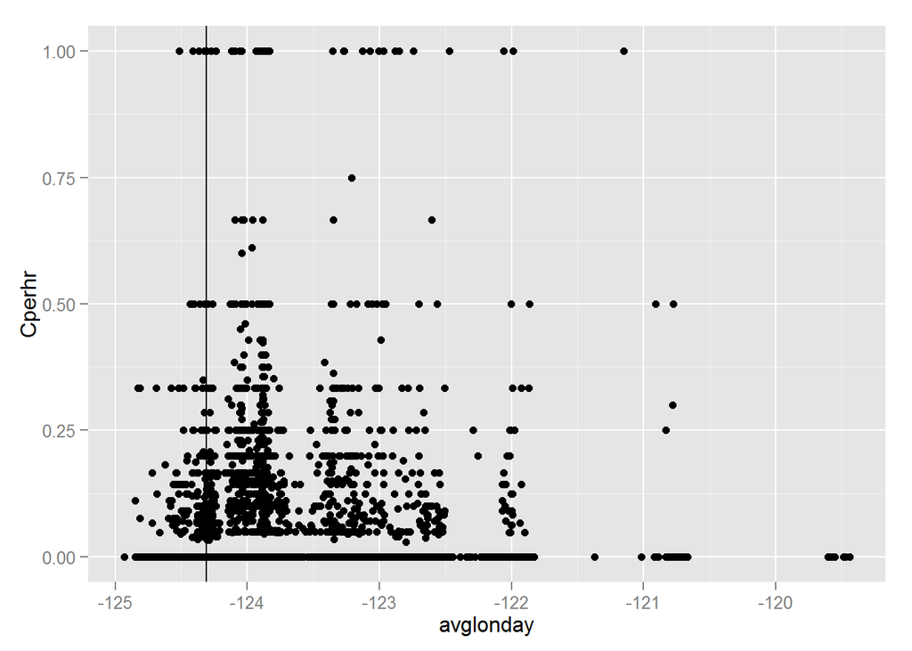

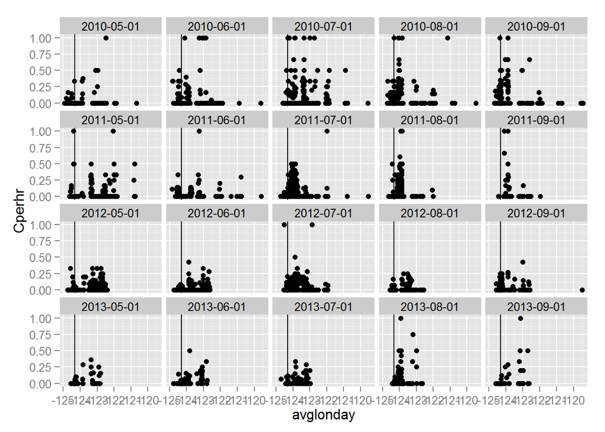

To standardize CPUE, methods presented here are similar to those in (Lynch, Shertzer, and Latour 2012), but instead of a delta-GLM approach, I used a delta-GAM model that incorporates nonlinear spatial effects. I present only the full models for both presence/absence and CPUE given presence. A model selection framework would be essential in selecting the most appropriate model and a cross validation scheme could provide measures of accuracy.

In this full model, month and year are additive fixed effects, the effect of month varies randomly by year, average daily latitude and longitude are nonlinear effects that vary per month, and a random effect of vessel accounts for differences among fishermen.

First, to model presence/absence, I assume a quasibinomial distribution as there is much overdispersion, some of which may be explained by schooling behavior. The model summary and diagnostic plot are below.

```
##  [1] "yfac"      "mfac"      "myfac"     "dmyfac"    "vessel_id"
##  [6] "hrsfished" "avglatday" "avglonday" "Cperday"   "Cperhr"
## [11] "presabs"
```

```
##
## Family: quasibinomial
## Link function: logit
##
## Formula:
## presabs ~ mfac + yfac + s(yfac, mfac, bs = "re") + s(avglatday,
##     by = mfac) + s(avglonday, by = mfac) + s(vessel_id, bs = "re")
##
## Parametric coefficients:
##                Estimate Std. Error t value Pr(>|t|)
## (Intercept)      -3.123      0.374   -8.34   <2e-16 ***
## mfac06            0.106      0.410    0.26    0.797
## mfac07            0.488      0.431    1.13    0.258
## mfac08            0.191      0.420    0.45    0.650
## mfac09            0.341      0.520    0.66    0.512
## yfac2011-01-01    0.329      0.288    1.14    0.253
## yfac2012-01-01    0.453      0.287    1.57    0.115
## yfac2013-01-01    0.518      0.309    1.68    0.093 .
## ---
## Signif. codes:  0 '***' 0.001 '**' 0.01 '*' 0.05 '.' 0.1 ' ' 1
##
## Approximate significance of smooth terms:
##                        edf Ref.df     F p-value
## s(yfac,mfac)          9.06  12.00  1.77 0.07009 .
## s(avglatday):mfac05   8.26   8.80  7.70 5.1e-11 ***
## s(avglatday):mfac06   6.27   7.17  9.50 6.4e-12 ***
## s(avglatday):mfac07   7.26   8.02 11.54 < 2e-16 ***
## s(avglatday):mfac08   8.03   8.49 10.14 1.2e-14 ***
## s(avglatday):mfac09   5.85   6.69  8.53 6.5e-10 ***
## s(avglonday):mfac05   8.07   8.59  5.29 6.7e-07 ***
## s(avglonday):mfac06   6.51   7.54  6.58 4.3e-08 ***
## s(avglonday):mfac07   7.40   7.99  6.81 6.4e-09 ***
## s(avglonday):mfac08   7.37   8.13  5.27 1.2e-06 ***
## s(avglonday):mfac09   7.11   7.67  3.36 0.00097 ***
## s(vessel_id)        122.99 225.00  1.20 1.5e-15 ***
## ---
## Signif. codes:  0 '***' 0.001 '**' 0.01 '*' 0.05 '.' 0.1 ' ' 1
##
## R-sq.(adj) =  0.326   Deviance explained =   36%
## GCV = 0.66101  Scale est. = 0.80459   n = 5686
```

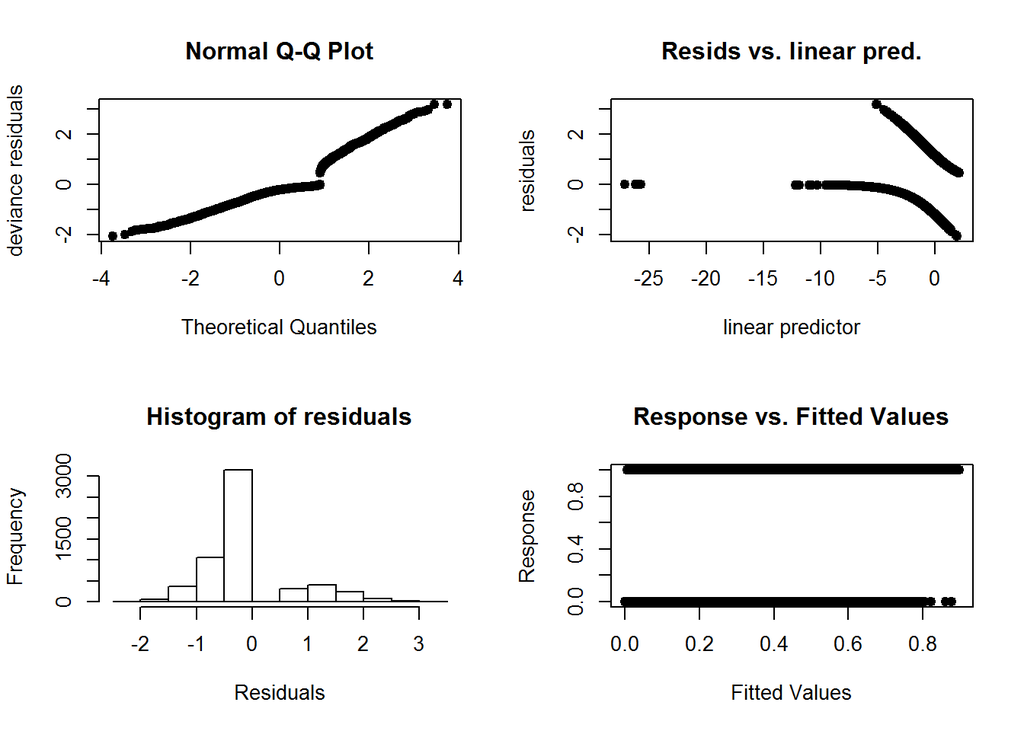

```
##
## Method: GCV   Optimizer: outer newton
## full convergence after 19 iterations.
## Gradient range [-1.304e-07,1.347e-06]
## (score 0.661 & scale 0.8046).
## Hessian positive definite, eigenvalue range [2.213e-05,0.00179].
## Model rank =  344 / 344
##
## Basis dimension (k) checking results. Low p-value (k-index<1) may
## indicate that k is too low, especially if edf is close to k'.
##
##                          k'     edf k-index p-value
## s(yfac,mfac)         20.000   9.057      NA      NA
## s(avglatday):mfac05   9.000   8.265   0.957    0.04
## s(avglatday):mfac06   9.000   6.271   0.957    0.02
## s(avglatday):mfac07   9.000   7.258   0.957    0.03
## s(avglatday):mfac08   9.000   8.030   0.957    0.02
## s(avglatday):mfac09   9.000   5.848   0.957    0.04
## s(avglonday):mfac05   9.000   8.072   0.949    0.02
## s(avglonday):mfac06   9.000   6.514   0.949    0.00
## s(avglonday):mfac07   9.000   7.398   0.949    0.01
## s(avglonday):mfac08   9.000   7.372   0.949    0.00
## s(avglonday):mfac09   9.000   7.105   0.949    0.01
## s(vessel_id)        226.000 122.989      NA      NA
```

The same explanatory variables are included in a full model of CPUE given presence, but I use a gamma distribution of errors. Here is a model summary followed by a diagnostic plot.

```
##
## Family: Gamma
## Link function: log
##
## Formula:
## Cperhr ~ mfac + yfac + s(yfac, mfac, bs = "re") + s(avglatday,
##     by = mfac) + s(avglonday, by = mfac) + s(vessel_id, bs = "re")
##
## Parametric coefficients:
##                Estimate Std. Error t value Pr(>|t|)
## (Intercept)     -1.4269     0.1676   -8.51  < 2e-16 ***
## mfac06          -0.0262     0.1765   -0.15   0.8819
## mfac07           0.1335     0.1691    0.79   0.4301
## mfac08           0.2246     0.1850    1.21   0.2250
## mfac09           0.4322     0.1810    2.39   0.0172 *
## yfac2011-01-01  -0.4146     0.1524   -2.72   0.0066 **
## yfac2012-01-01  -0.8633     0.1542   -5.60  2.9e-08 ***
## yfac2013-01-01  -0.7219     0.1657   -4.36  1.5e-05 ***
## ---
## Signif. codes:  0 '***' 0.001 '**' 0.01 '*' 0.05 '.' 0.1 ' ' 1
##
## Approximate significance of smooth terms:
##                       edf Ref.df    F p-value
## s(yfac,mfac)         8.35  12.00 4.36 8.6e-05 ***
## s(avglatday):mfac05  1.00   1.00 1.93  0.1649
## s(avglatday):mfac06  1.00   1.00 0.20  0.6565
## s(avglatday):mfac07  1.00   1.00 0.07  0.7902
## s(avglatday):mfac08  8.19   8.63 2.98  0.0021 **
## s(avglatday):mfac09  1.00   1.00 2.05  0.1526
## s(avglonday):mfac05  1.25   1.45 0.07  0.8722
## s(avglonday):mfac06  7.01   7.94 1.49  0.1579
## s(avglonday):mfac07  6.00   7.04 1.25  0.2717
## s(avglonday):mfac08  1.00   1.00 0.08  0.7723
## s(avglonday):mfac09  1.00   1.00 0.80  0.3700
## s(vessel_id)        88.88 143.00 1.60 1.2e-14 ***
## ---
## Signif. codes:  0 '***' 0.001 '**' 0.01 '*' 0.05 '.' 0.1 ' ' 1
##
## R-sq.(adj) =  0.293   Deviance explained =   48%
## GCV = 0.43766  Scale est. = 0.43371   n = 1050
```

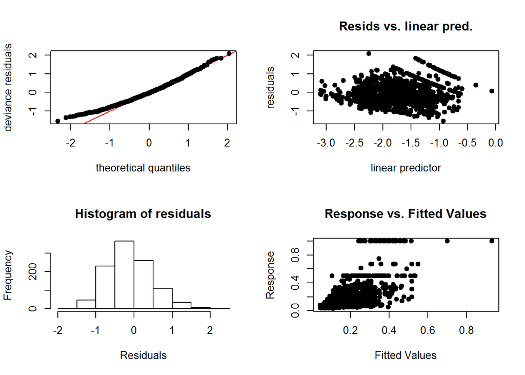

```
##
## Method: GCV   Optimizer: outer newton
## full convergence after 11 iterations.
## Gradient range [-2.924e-07,6.097e-08]
## (score 0.4377 & scale 0.4337).
## Hessian positive definite, eigenvalue range [4.885e-09,0.01056].
## Model rank =  262 / 262
##
## Basis dimension (k) checking results. Low p-value (k-index<1) may
## indicate that k is too low, especially if edf is close to k'.
##
##                          k'     edf k-index p-value
## s(yfac,mfac)         20.000   8.345      NA      NA
## s(avglatday):mfac05   9.000   1.000   1.009    0.92
## s(avglatday):mfac06   9.000   1.000   1.009    0.90
## s(avglatday):mfac07   9.000   1.000   1.009    0.94
## s(avglatday):mfac08   9.000   8.187   1.009    0.94
## s(avglatday):mfac09   9.000   1.000   1.009    0.95
## s(avglonday):mfac05   9.000   1.249   0.995    0.90
## s(avglonday):mfac06   9.000   7.012   0.995    0.87
## s(avglonday):mfac07   9.000   6.002   0.995    0.90
## s(avglonday):mfac08   9.000   1.001   0.995    0.88
## s(avglonday):mfac09   9.000   1.000   0.995    0.80
## s(vessel_id)        144.000  88.879      NA      NA
```

Lastly, to obtain a time series of abundance indices, year effects are extracted from both models and multiplied (after applying a bias correction). The plot of estimated indices is below, but of course estimates of standard errors are vital to interpreting these results and are likely to be substantial.

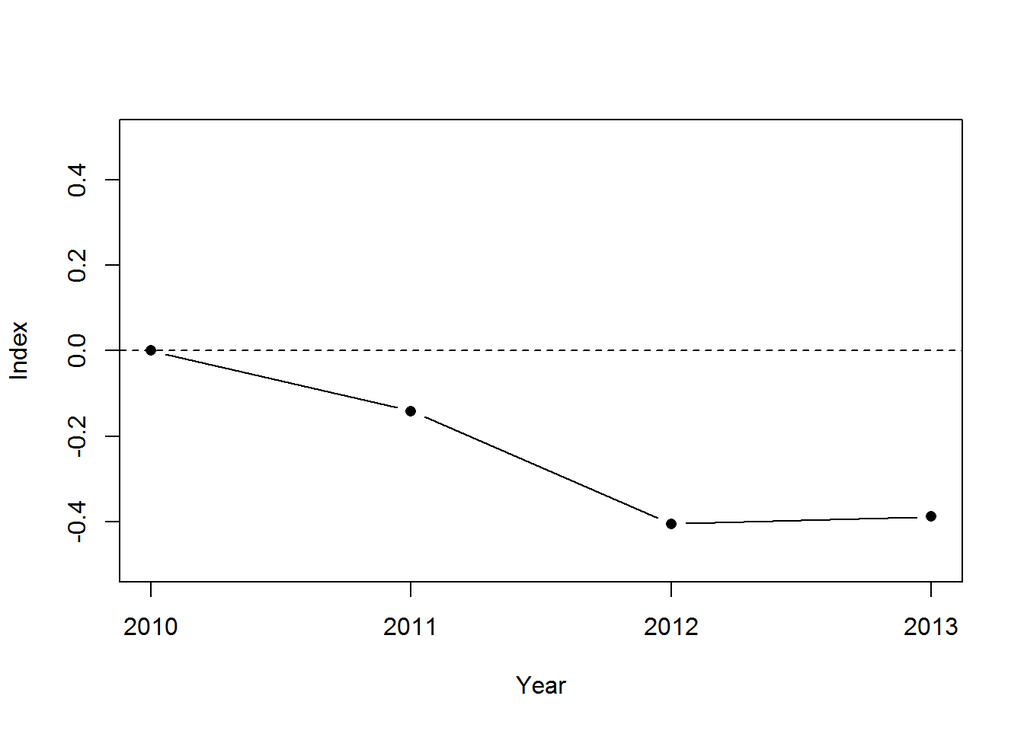

References

Lynch, Patrick D, Kyle W Shertzer, and Robert J Latour. 2012. “Performance of Methods Used to Estimate Indices of Abundance for Highly Migratory Species.” *Fisheries Research* 125. Elsevier: 27–39.